# Ampliseq ASV analysis: depth, batch effect, NMDS, sPLS-DA and sPLS regression

Author

Abu B Siddique

Published

October 15, 2026

Sources: [mixMC HMP case study](https://mixomics.org/mixmc/hmp-bodysites-case-study/), [PLSDAbatch](https://evayiwenwang.github.io/PLSDAbatch_workflow/), Nygaard et al. 2016 *Biostatistics* (batch correction and inflated group effects).

# 1 Analysis plan

| # | Step | Question | Method | How `run` is handled | Output |
| --- | --- | --- | --- | --- | --- |
| 1 | Sequencing depth | Is depth adequate and is it linked to run or District? | Library sizes, rarefaction curves, rarefaction slope, depth vs PC1 | Depth tested against run | Keep/drop decision |
| 2 | Design check | Can run and District be separated at all? | Run × District table, Cramér’s V, env vars vs run | – | Go/no-go for correction |
| 3 | Preprocessing | – | Filter rare ASVs, CLR (pseudocount 1) | – | `clr_raw` |
| 4 | Batch effect | How much variance is run? Does correction remove it without removing District? | PCA, PERMANOVA, variance partitioning, silhouette; `limma::removeBatchEffect` vs per-run centering (vs PLSDA-batch) | Corrected matrix `X_bc` | Chosen correction |
| 5 | NMDS | Do samples group by District, run, shortName? | NMDS on Bray–Curtis (raw) and Aitchison (raw and corrected); PERMANOVA, betadisper, envfit | Run as a PERMANOVA term; permutations within run | Ordination figures + tests |
| 6 | sPLS-DA (District) | Which ASVs discriminate Districts? | Tuned sPLS-DA, repeated CV, permutation test, leave-one-run-out | Corrected CLR; permutations redo the correction | BER, selected ASVs (Order-Genus) |
| 7 | sPLS regression (pH, DO, Temp, Ammonia) | Can the community predict each variable, and which ASVs drive it? | sPLS1 per variable, LOO-CV Q², permutation test, VIP; RDA as a joint model | Correction protects the variable; RDA uses `Condition(run)` | Q², driver ASVs (Order-Genus) |
| 8 | Other ML | Do results hold with a different model? Does the microbiome add beyond the environment? | Random Forest (genus level), env-only vs microbiome vs both | Label-free per-run centering | Balanced accuracy, Q², importance |

**NotePLS-DA vs PLS for continuous variables**

PLS-**DA** is for categories (District). For pH, DO, Temp and Ammonia the matching method is PLS **regression**: sPLS1 (one variable at a time; best for “which ASVs drive pH”) or sPLS2 (all four jointly). Both are in mixOmics and give loadings and VIP scores the same way.

# 2 Setup

```r
# install.packages(c("vegan", "ggplot2", "ggrepel", "ranger", "readr", "permute"))
# if (!require("BiocManager")) install.packages("BiocManager")
# BiocManager::install(c("phyloseq", "mixOmics", "limma"))
# optional: BiocManager::install("PLSDAbatch")
```

```r
suppressPackageStartupMessages({
  library(phyloseq)
  library(vegan)
  library(limma)
  library(ggplot2)
  library(ggrepel)
  library(mixOmics)   # loaded after vegan; mixOmics:: prefixes used anyway
  library(cluster)
  library(permute)
})

set.seed(5249)
theme_set(theme_bw(base_size = 11))

batch_col <- params$batch_col
group_col <- params$group_col
name_col  <- params$name_col
env_vars  <- unlist(params$env_vars)
bc_method <- params$bc_method
```

## 2.1 Load data and remove the positive control

```r
# setwd("C:/Users/auue0001/OneDrive - Sveriges lantbruksuniversitet/slubi/workshops/ML4LS")

ps <- readRDS(params$ps_path)
# ps <- readRDS("project/dada2_phyloseq.rds")

metadata_df <- as.data.frame(readr::read_delim(params$meta_path, delim = "\t",
                                               escape_double = FALSE, trim_ws = TRUE))
rownames(metadata_df) <- metadata_df$sampleID
sample_data(ps) <- sample_data(metadata_df)

ps <- subset_samples(ps, Group %in% c("1", "2", "3"))   # drop positive control
ps <- prune_taxa(taxa_sums(ps) > 0, ps)                 # drop ASVs now absent
ps
```

```
phyloseq-class experiment-level object
otu_table()   OTU Table:         [ 3335 taxa and 17 samples ]
sample_data() Sample Data:       [ 17 samples by 11 sample variables ]
tax_table()   Taxonomy Table:    [ 3335 taxa by 10 taxonomic ranks ]
phy_tree()    Phylogenetic Tree: [ 3335 tips and 3334 internal nodes ]
```

## 2.2 Short ASV IDs and “Order-Genus” labels

```r
# ampliseq/DADA2 taxa names are long hashes or sequences: rename to ASV1, ASV2, ...
asv_map <- data.frame(ASV = paste0("ASV", seq_len(ntaxa(ps))), original = taxa_names(ps))
taxa_names(ps) <- asv_map$ASV

tax <- as.data.frame(as(tax_table(ps), "matrix"), stringsAsFactors = FALSE)
names(tax) <- tools::toTitleCase(tolower(names(tax)))   # "genus" -> "Genus"

clean_rank <- function(v) {
  v <- trimws(sub("^[a-zA-Z]__", "", as.character(v)))  # strip SILVA/GTDB "g__" prefixes
  bad <- is.na(v) | v == "" |
    grepl("^(uncultured|unclassified|unknown|metagenome|NA$)", v, ignore.case = TRUE)
  v[bad] <- NA
  v
}
ranks <- intersect(c("Kingdom", "Domain", "Phylum", "Class", "Order", "Family", "Genus"),
                   names(tax))
for (r in ranks) tax[[r]] <- clean_rank(tax[[r]])
getr <- function(r) if (r %in% names(tax)) tax[[r]] else rep(NA_character_, nrow(tax))

# Order part: Order, else "c_<Class>"; Genus part: Genus, else "f_<Family>"
ord_part <- ifelse(!is.na(getr("Order")), getr("Order"),
                   ifelse(!is.na(getr("Class")), paste0("c_", getr("Class")), "Unclassified"))
gen_part <- ifelse(!is.na(getr("Genus")), getr("Genus"),
                   ifelse(!is.na(getr("Family")), paste0("f_", getr("Family")), "unclassified"))

tax$OrderGenus <- paste(ord_part, gen_part, sep = "-")              # e.g. "Bacillales-Bacillus"
tax$Label      <- paste0(tax$OrderGenus, " (", rownames(tax), ")")   # unique plot label
head(tax[, c("OrderGenus", "Label")])
```

```
                    OrderGenus                            Label
ASV1 Unclassified-unclassified Unclassified-unclassified (ASV1)
ASV2 Unclassified-unclassified Unclassified-unclassified (ASV2)
ASV3 Unclassified-unclassified Unclassified-unclassified (ASV3)
ASV4 Unclassified-unclassified Unclassified-unclassified (ASV4)
ASV5 Unclassified-unclassified Unclassified-unclassified (ASV5)
ASV6 Unclassified-unclassified Unclassified-unclassified (ASV6)
```

## 2.3 Count matrix and metadata

```r
X_raw <- as(otu_table(ps), "matrix")
if (taxa_are_rows(ps)) X_raw <- t(X_raw)       # samples as rows

meta <- data.frame(sample_data(ps), check.names = FALSE)
meta <- meta[rownames(X_raw), , drop = FALSE]
stopifnot(identical(rownames(meta), rownames(X_raw)))

meta[[batch_col]] <- droplevels(factor(meta[[batch_col]]))
meta[[group_col]] <- droplevels(factor(meta[[group_col]]))
meta[[name_col]]  <- factor(meta[[name_col]])
for (v in env_vars) {                        # "7,2" -> 7.2 if read as text
  if (!is.numeric(meta[[v]])) meta[[v]] <- as.numeric(gsub(",", ".", as.character(meta[[v]])))
}

dim(X_raw)
```

```
[1]   17 3335
```

```r
summary(meta[, c(batch_col, group_col, env_vars)])
```

```
 run          District       pH              DO             Temp
 A:11   Cumilla   :6   Min.   :7.750   Min.   :5.230   Min.   :23.87
 B: 6   Gazipur   :3   1st Qu.:8.030   1st Qu.:5.930   1st Qu.:26.90
        Mymensingh:8   Median :8.130   Median :7.000   Median :27.30
                       Mean   :8.219   Mean   :6.992   Mean   :28.23
                       3rd Qu.:8.600   3rd Qu.:7.830   3rd Qu.:30.92
                       Max.   :8.730   Max.   :8.800   Max.   :33.32
    Ammonia
 Min.   :0.0300
 1st Qu.:0.1000
 Median :0.1800
 Mean   :0.2559
 3rd Qu.:0.4200
 Max.   :0.6100
```

# 3 Sequencing depth

```r
depth <- data.frame(sample = rownames(X_raw),
                    reads  = rowSums(X_raw),
                    nASV   = rowSums(X_raw > 0),
                    meta[, c(batch_col, group_col, name_col)],
                    check.names = FALSE)
summary(depth$reads)
```

```
   Min. 1st Qu.  Median    Mean 3rd Qu.    Max.
  61447   78323   82998  105869  126823  191855
```

```r
cat("max/min depth ratio:", round(max(depth$reads) / min(depth$reads), 1), "\n")
```

```
max/min depth ratio: 3.1
```

```r
depth[depth$reads < params$min_depth, ]       # samples below the threshold
```

```
[1] sample    reads     nASV      run       District  shortName
<0 rows> (or 0-length row.names)
```

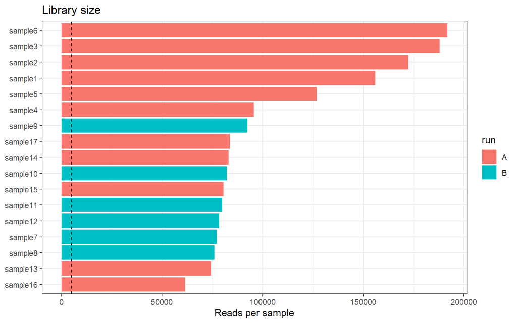

```r
ggplot(depth, aes(reorder(sample, reads), reads, fill = .data[[batch_col]])) +
  geom_col() + coord_flip() +
  geom_hline(yintercept = params$min_depth, linetype = 2) +
  labs(x = NULL, y = "Reads per sample", title = "Library size")
```

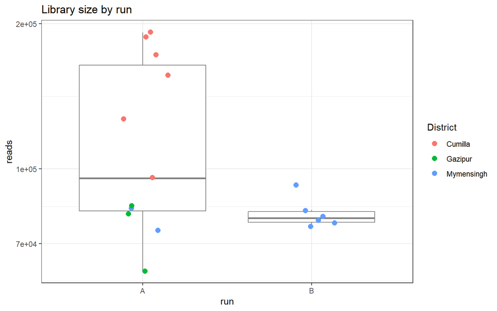

```r
ggplot(depth, aes(.data[[batch_col]], reads, colour = .data[[group_col]])) +
  geom_boxplot(outlier.shape = NA, colour = "grey50") +
  geom_jitter(width = 0.15, size = 2.5) +
  scale_y_log10() + labs(title = "Library size by run")
```

```r
# Is depth linked to run or District? (a depth difference by run is part of the batch effect)
anova(lm(as.formula(paste("log10(reads) ~", batch_col, "+", group_col)), data = depth))
```

```
Analysis of Variance Table

Response: log10(reads)
          Df   Sum Sq  Mean Sq F value   Pr(>F)
run        1 0.071722 0.071722  10.940 0.005664 **
District   2 0.240832 0.120416  18.368 0.000163 ***
Residuals 13 0.085224 0.006556
---
Signif. codes:  0 '***' 0.001 '**' 0.01 '*' 0.05 '.' 0.1 ' ' 1
```

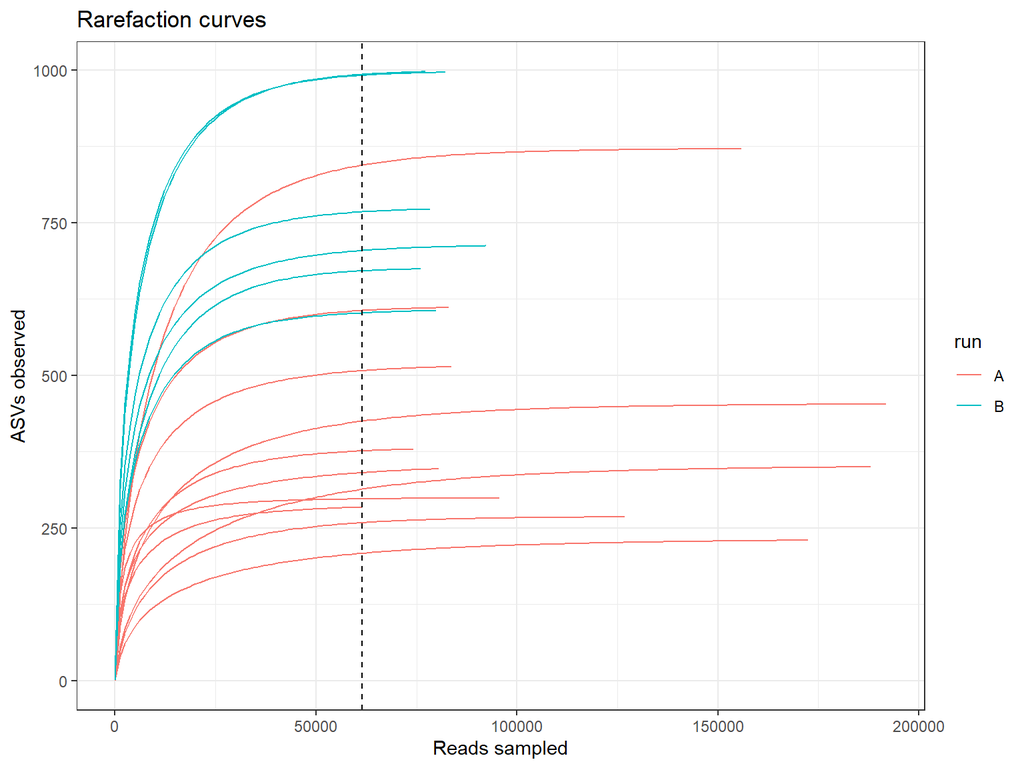

```r
# Rarefaction curves: a curve that is still rising at its end = undersampled
rc <- vegan::rarecurve(X_raw, step = max(100, round(min(depth$reads) / 50)), tidy = TRUE)
rc$run <- meta[as.character(rc$Site), batch_col]
ggplot(rc, aes(Sample, Species, group = Site, colour = run)) +
  geom_line() +
  geom_vline(xintercept = min(depth$reads), linetype = 2) +
  labs(x = "Reads sampled", y = "ASVs observed", title = "Rarefaction curves")
```

```r
# Slope at the smallest library size: new ASVs per extra read (close to 0 = saturated)
depth$slope_at_min <- vegan::rareslope(X_raw, sample = min(depth$reads))
depth[order(-depth$slope_at_min), c("sample", "reads", "nASV", "slope_at_min")]
```

```
           sample  reads nASV slope_at_min
sample1   sample1 155948  871 0.0011399341
sample3   sample3 188003  350 0.0009773292
sample6   sample6 191855  453 0.0008484839
sample2   sample2 172427  230 0.0005501651
sample9   sample9  92390  712 0.0004773700
sample17 sample17  83782  514 0.0004700153
sample7   sample7  77187  997 0.0004446569
sample15 sample15  80614  347 0.0004384591
sample5   sample5 126823  268 0.0004160360
sample10 sample10  82163  996 0.0004136003
sample12 sample12  78323  772 0.0004086962
sample14 sample14  82998  611 0.0003871014
sample8   sample8  76076  674 0.0003443968
sample11 sample11  79873  606 0.0003221199
sample13 sample13  74275  379 0.0003069119
sample4   sample4  95590  299 0.0000852008
sample16 sample16  61447  284 0.0000000000
```

**TipGood’s coverage is not informative here**

DADA2 removes singletons, so Good’s coverage (1 − singletons/reads) is ~1 for every sample. Use the rarefaction curves and slope instead.

## 3.1 Alpha diversity at even depth (depth-controlled)

Rarefying is used **only** here. Multivariate analyses use CLR on unrarefied counts.

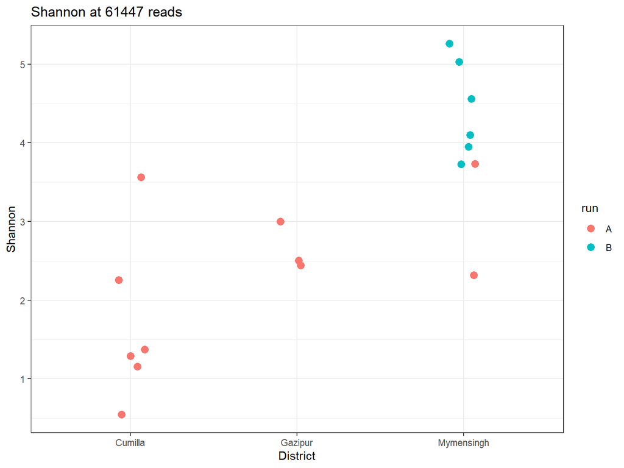

```r
ps_rare <- rarefy_even_depth(ps, sample.size = min(depth$reads), rngseed = 5249,
                             replace = FALSE, verbose = FALSE)
alpha <- estimate_richness(ps_rare, measures = c("Observed", "Shannon"))
rownames(alpha) <- sample_names(ps_rare)   # estimate_richness can mangle names (e.g. "X1A")
alpha <- cbind(alpha, meta[rownames(alpha), c(batch_col, group_col)])

ggplot(alpha, aes(.data[[group_col]], Shannon, colour = .data[[batch_col]])) +
  geom_point(size = 3, position = position_jitter(width = 0.1)) +
  labs(title = paste("Shannon at", min(depth$reads), "reads"))
```

```r
# District effect adjusted for run (type II: each term after the other)
drop1(lm(as.formula(paste("Shannon ~", group_col, "+", batch_col)), data = alpha), test = "F")
```

```
Single term deletions

Model:
Shannon ~ District + run
         Df Sum of Sq     RSS     AIC F value  Pr(>F)
<none>                 8.7646 -3.2623
District  2    3.4763 12.2409 -1.5833  2.5781 0.11402
run       1    2.9908 11.7555 -0.2712  4.4361 0.05519 .
---
Signif. codes:  0 '***' 0.001 '**' 0.01 '*' 0.05 '.' 0.1 ' ' 1
```

# 4 Design check: is run confounded with District?

```r
tab <- table(meta[[group_col]], meta[[batch_col]], dnn = c(group_col, batch_col))
tab
```

```
            run
District     A B
  Cumilla    6 0
  Gazipur    3 0
  Mymensingh 2 6
```

```r
chi <- suppressWarnings(chisq.test(tab))
cramer_v <- sqrt(unname(chi$statistic) / (sum(tab) * (min(dim(tab)) - 1)))
cat("Cramér's V (District vs run):", round(cramer_v, 2), "  (0 = balanced, 1 = fully confounded)\n")
```

```
Cramér's V (District vs run): 0.78   (0 = balanced, 1 = fully confounded)
```

```r
# Fully confounded if every District sits in one run, or every run holds one District
fully_confounded <- all(rowSums(tab > 0) == 1) || all(colSums(tab > 0) == 1)
if (fully_confounded) {
  warning("District and run are fully confounded: batch correction would remove the ",
          "District signal. Do NOT correct; analyse within run or report run+District jointly.")
}
```

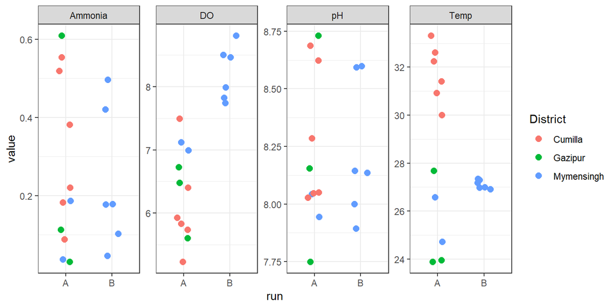

```r
# Are the measurements themselves different between runs?
env_long <- do.call(rbind, lapply(env_vars, function(v)
  data.frame(variable = v, value = meta[[v]], run = meta[[batch_col]],
             group = meta[[group_col]])))
ggplot(env_long, aes(run, value, colour = group)) +
  geom_jitter(width = 0.15, size = 2.5) +
  facet_wrap(~ variable, scales = "free_y", nrow = 1) +
  labs(x = batch_col, colour = group_col)
```

```r
# Share of each variable's variance explained by run (R^2 of lm(var ~ run))
sapply(env_vars, function(v) {
  ok <- !is.na(meta[[v]])
  round(summary(lm(meta[[v]][ok] ~ meta[[batch_col]][ok]))$r.squared, 2)
})
```

```
     pH      DO    Temp Ammonia
   0.00    0.70    0.08    0.00
```

**Warning**

If a variable’s R² with run is close to 1 (e.g. Temp measured once per run), that variable is confounded with run. Then its microbiome association cannot be separated from the batch effect, and the sPLS model for it should be reported with that caveat.

# 5 Preprocessing: filtering and CLR

```r
# Keep ASVs with > 0.01% of all reads and present in >= 2 samples
keep <- colSums(X_raw) / sum(X_raw) > 1e-4 & colSums(X_raw > 0) >= 2
X_f  <- X_raw[, keep]
dim(X_f)
```

```
[1]  17 465
```

```r
cat("Reads retained:", round(100 * sum(X_f) / sum(X_raw), 1), "%\n")
```

```
Reads retained: 94.7 %
```

```r
clr <- function(x) { lx <- log(x); lx - rowMeans(lx) }   # samples as rows
clr_raw <- clr(X_f + 1)
```

```r
# Depth artefact check: does depth correlate with the main axes of variation?
pc_raw <- prcomp(clr_raw)$x[, 1:3]
round(cor(log10(depth$reads), pc_raw, method = "spearman"), 2)
```

```
       PC1   PC2   PC3
[1,] -0.01 -0.39 -0.47
```

# 6 Batch effect

## 6.1 Helper functions

```r
## Batch correction on a CLR matrix (samples x ASVs)
##  limma : removeBatchEffect, protecting `design` (e.g. ~ District) -- uses labels
##  center: subtract each run's mean per ASV                         -- label-free
batch_correct <- function(clr, batch, design = NULL, method = bc_method) {
  batch <- droplevels(factor(batch))
  if (method == "none" || nlevels(batch) < 2) return(clr)
  if (method == "center") {
    out <- clr
    for (b in levels(batch)) {
      i <- batch == b
      out[i, ] <- sweep(clr[i, , drop = FALSE], 2, colMeans(clr[i, , drop = FALSE]))
    }
    return(sweep(out, 2, colMeans(clr), "+"))
  }
  if (method == "limma") {
    if (is.null(design)) design <- matrix(1, nrow(clr), 1)
    full <- cbind(design, model.matrix(~ batch)[, -1, drop = FALSE])
    if (qr(full)$rank < ncol(full)) {
      warning("Batch is confounded with the protected design; returning uncorrected data.")
      return(clr)
    }
    return(t(limma::removeBatchEffect(t(clr), batch = batch, design = design)))
  }
  stop("Unknown method: ", method)
}

## How much variance is batch vs group, before/after correction
batch_metrics <- function(X, meta) {
  vp <- vegan::varpart(X, reformulate(group_col), reformulate(batch_col), data = meta)
  fr <- vp$part$indfract$Adj.R.squared          # [a] group only, [b] batch only, [c] shared
  d  <- dist(X)
  sil <- function(g) mean(cluster::silhouette(as.integer(factor(g)), d)[, "sil_width"])
  data.frame(R2adj_District_only = fr[1], R2adj_run_only = fr[2], R2adj_shared = fr[3],
             silhouette_run = sil(meta[[batch_col]]),
             silhouette_District = sil(meta[[group_col]]))
}

pca_plot <- function(X, title) {
  p  <- prcomp(X)
  ve <- round(100 * p$sdev^2 / sum(p$sdev^2), 1)
  df <- data.frame(p$x[, 1:2], meta[, c(batch_col, group_col)], check.names = FALSE)
  ggplot(df, aes(PC1, PC2, colour = .data[[batch_col]], shape = .data[[group_col]])) +
    geom_point(size = 3) +
    labs(x = paste0("PC1 (", ve[1], "%)"), y = paste0("PC2 (", ve[2], "%)"), title = title)
}
```

## 6.2 Assess the batch effect (uncorrected data)

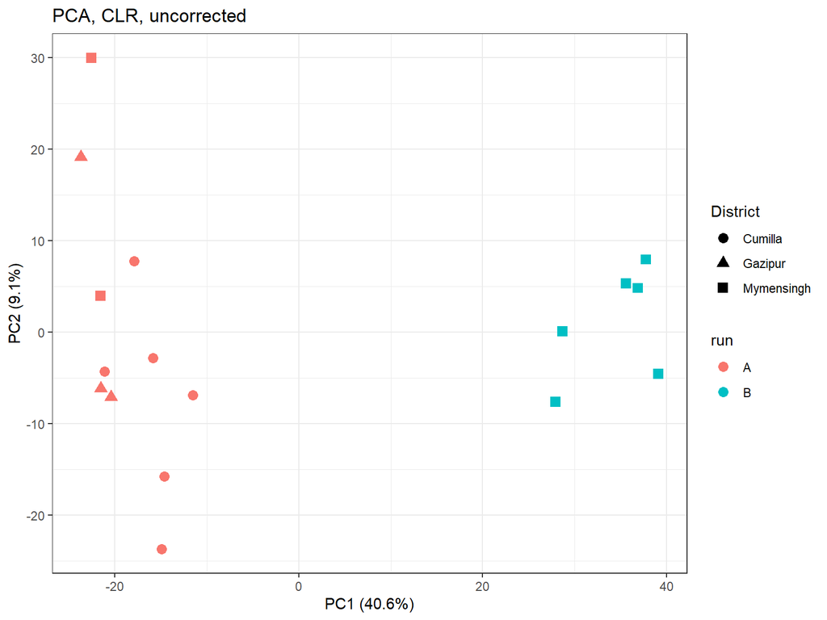

```r
pca_plot(clr_raw, "PCA, CLR, uncorrected")
```

```r
# PERMANOVA on Aitchison distance: each term adjusted for the other (by = "margin")
d_ait_raw <- dist(clr_raw)
adonis2(as.formula(paste("d_ait_raw ~", group_col, "+", batch_col)),
        data = meta, by = "margin", permutations = 999)
```

```
Permutation test for adonis under reduced model
Marginal effects of terms
Permutation: free
Number of permutations: 999

adonis2(formula = as.formula(paste("d_ait_raw ~", group_col, "+", batch_col)), data = meta, permutations = 999, by = "margin")
         Df SumOfSqs      R2      F Pr(>F)
District  2   3042.3 0.11033 1.4555  0.151
run       1   5510.6 0.19985 5.2729  0.001 ***
Residual 13  13586.0 0.49271
Total    16  27574.0 1.00000
---
Signif. codes:  0 '***' 0.001 '**' 0.01 '*' 0.05 '.' 0.1 ' ' 1
```

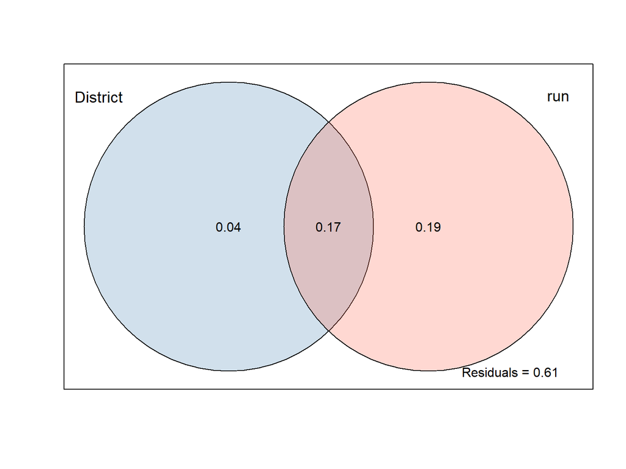

```r
# Variance partitioning: District-only, run-only and shared fractions
vp_raw <- vegan::varpart(clr_raw, reformulate(group_col), reformulate(batch_col), data = meta)
plot(vp_raw, Xnames = c(group_col, batch_col), bg = c("steelblue", "tomato"))
```

## 6.3 Correct and compare methods

```r
design_grp <- model.matrix(reformulate(group_col), data = meta)

X_list <- list(
  none   = clr_raw,
  center = batch_correct(clr_raw, meta[[batch_col]], method = "center"),
  limma  = batch_correct(clr_raw, meta[[batch_col]], design = design_grp, method = "limma")
)

## Optional: PLSDA-batch, designed for microbiome data (Wang & Le Cao 2023)
# library(PLSDAbatch)
# pb <- PLSDA_batch(X = clr_raw, Y.trt = meta[[group_col]], Y.bat = meta[[batch_col]],
#                   ncomp.trt = 1, ncomp.bat = 1, balance = FALSE)  # FALSE = weighted, for unbalanced designs
# X_list$plsda_batch <- pb$X.nobatch

bm <- do.call(rbind, lapply(X_list, batch_metrics, meta = meta))
round(bm, 3)
```

```
       R2adj_District_only R2adj_run_only R2adj_shared silhouette_run
none                 0.037          0.185        0.172          0.319
center               0.061         -0.013       -0.053         -0.065
limma                0.054         -0.063        0.122          0.050
       silhouette_District
none                 0.067
center              -0.023
limma                0.076
```

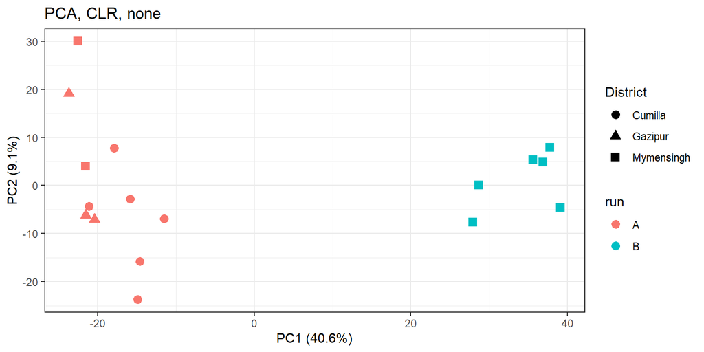

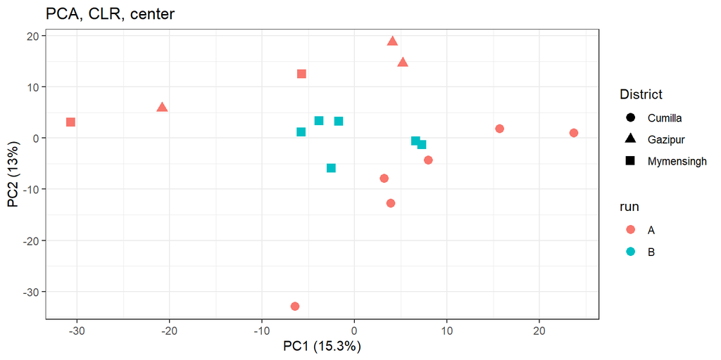

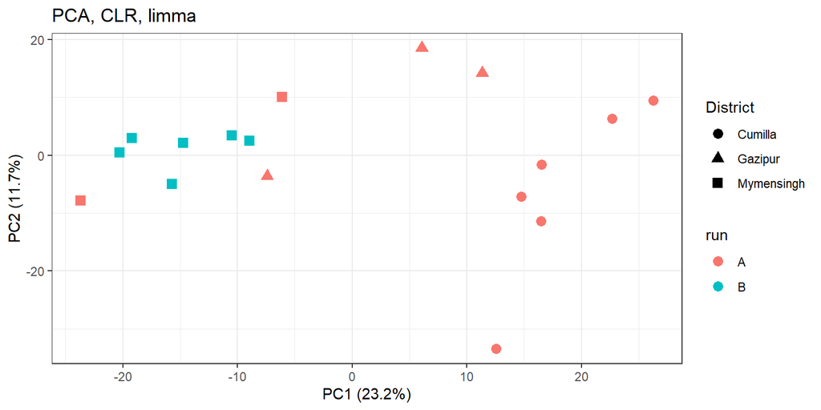

```r
for (m in names(X_list)) print(pca_plot(X_list[[m]], paste("PCA, CLR,", m)))
```

**What a good correction looks like:** `R2adj_run_only` and `silhouette_run` drop toward 0, while `R2adj_District_only` stays the same or rises.

```r
X_bc <- X_list[[bc_method]]      # set bc_method in the YAML header
cat("Using batch correction:", bc_method, "\n")
```

```
Using batch correction: limma
```

**WarningWhich correction to trust**

- **limma with District protected** removes run well, but because it uses the District labels, District separation on the corrected data is somewhat optimistic when the design is unbalanced (Nygaard et al. 2016). The permutation tests below redo the correction for every permuted label set, so the p-values stay fair.
- **Per-run centering** uses no labels, so it is safe inside cross-validation, but it removes some District signal if Districts are unevenly spread across runs.
- **Statistical tests** (PERMANOVA, RDA) use the uncorrected CLR with run as a term instead of corrected data.

# 7 NMDS on District, run and shortName

```r
rel <- X_raw / rowSums(X_raw)                     # relative abundance, all ASVs

d_list <- list(
  "Bray-Curtis (raw)"          = vegan::vegdist(rel, method = "bray"),
  "Aitchison (raw)"            = dist(clr_raw),
  "Aitchison (batch-corrected)" = dist(X_bc)
)

set.seed(5249)
nmds_list <- lapply(d_list, function(d) vegan::metaMDS(d, k = 2, trymax = 200, trace = 0))
sapply(nmds_list, function(m) round(m$stress, 3))   # < 0.1 good, 0.1-0.2 fair, > 0.2 poor
```

```
          Bray-Curtis (raw)             Aitchison (raw)
                      0.106                       0.065
Aitchison (batch-corrected)
                      0.130
```

```r
nmds_df <- do.call(rbind, lapply(names(nmds_list), function(nm) {
  m <- nmds_list[[nm]]
  data.frame(NMDS1 = m$points[, 1], NMDS2 = m$points[, 2],
             method = paste0(nm, "\nstress = ", round(m$stress, 3)),
             meta[, c(batch_col, group_col, name_col, env_vars)], check.names = FALSE)
}))
```

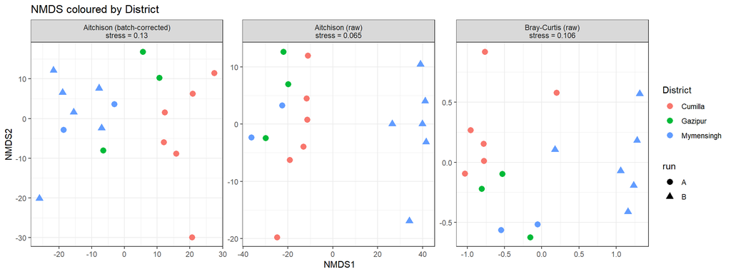

```r
plot_nmds <- function(df, var) {
  shape_var <- if (var == batch_col) group_col else batch_col
  p <- ggplot(df, aes(NMDS1, NMDS2)) + facet_wrap(~ method, scales = "free", nrow = 1)
  if (nlevels(factor(df[[var]])) <= 12) {
    p <- p + geom_point(aes(colour = .data[[var]], shape = .data[[shape_var]]), size = 3)
  } else {                           # many levels (e.g. unique site names): label points
    p <- p + geom_point(aes(colour = .data[[group_col]], shape = .data[[batch_col]]), size = 2.5) +
      ggrepel::geom_text_repel(aes(label = .data[[var]]), size = 2.6, max.overlaps = 30)
  }
  p + labs(title = paste("NMDS coloured by", var))
}

plot_nmds(nmds_df, group_col)
```

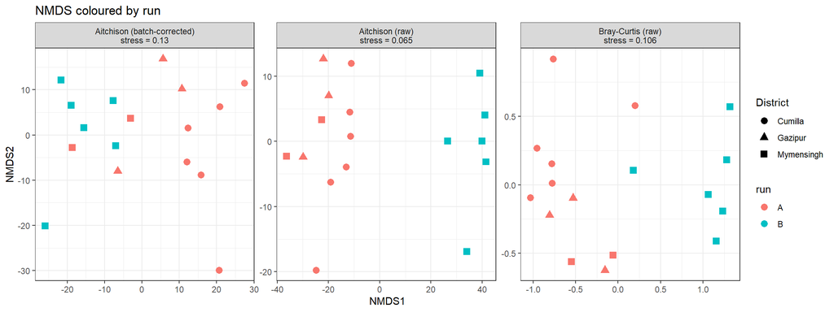

```r
plot_nmds(nmds_df, batch_col)
```

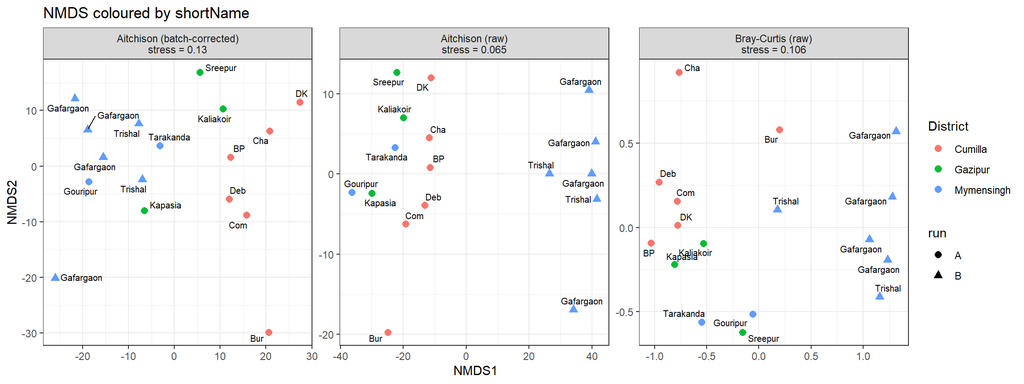

```r
plot_nmds(nmds_df, name_col)
```

## 7.1 Tests: PERMANOVA and dispersion

```r
perm_within_run <- how(nperm = 999, blocks = meta[[batch_col]])

for (nm in names(d_list)[1:2]) {          # tests on raw distances, run in the model
  d <- d_list[[nm]]
  cat("\n=====", nm, "=====\n")
  print(adonis2(as.formula(paste("d ~", group_col, "+", batch_col)),
                data = meta, by = "margin", permutations = 999))
  # District with permutations restricted within run
  print(adonis2(as.formula(paste("d ~", group_col)), data = meta,
                permutations = perm_within_run))
  # shortName only testable if names repeat (replicates)
  if (nlevels(meta[[name_col]]) < nrow(meta)) {
    print(adonis2(as.formula(paste("d ~", name_col)), data = meta, permutations = 999))
  }
  # Homogeneity of dispersion: a significant PERMANOVA can come from spread, not location
  for (g in c(group_col, batch_col)) {
    cat("betadisper:", g, "\n")
    print(permutest(betadisper(d, meta[[g]]), permutations = 999)$tab)
  }
}
```

```
===== Bray-Curtis (raw) =====
Permutation test for adonis under reduced model
Marginal effects of terms
Permutation: free
Number of permutations: 999

adonis2(formula = as.formula(paste("d ~", group_col, "+", batch_col)), data = meta, permutations = 999, by = "margin")
         Df SumOfSqs      R2      F Pr(>F)
District  2   0.7663 0.14643 1.8161  0.061 .
run       1   0.8580 0.16394 4.0666  0.002 **
Residual 13   2.7428 0.52409
Total    16   5.2335 1.00000
---
Signif. codes:  0 '***' 0.001 '**' 0.01 '*' 0.05 '.' 0.1 ' ' 1
Permutation test for adonis under reduced model
Blocks:  meta[[batch_col]]
Permutation: free
Number of permutations: 999

adonis2(formula = as.formula(paste("d ~", group_col)), data = meta, permutations = perm_within_run)
         Df SumOfSqs      R2      F Pr(>F)
Model     2   1.6326 0.31196 3.1739  0.121
Residual 14   3.6008 0.68804
Total    16   5.2335 1.00000
Permutation test for adonis under reduced model
Permutation: free
Number of permutations: 999

adonis2(formula = as.formula(paste("d ~", name_col)), data = meta, permutations = 999)
         Df SumOfSqs      R2      F Pr(>F)
Model    12   4.4685 0.85384 1.9472  0.022 *
Residual  4   0.7649 0.14616
Total    16   5.2335 1.00000
---
Signif. codes:  0 '***' 0.001 '**' 0.01 '*' 0.05 '.' 0.1 ' ' 1
betadisper: District
          Df     Sum Sq    Mean Sq        F N.Perm Pr(>F)
Groups     2 0.08609413 0.04304706 1.307707    999  0.291
Residuals 14 0.46085150 0.03291796       NA     NA     NA
betadisper: run
```

[output cut: 32 more lines]

```
adonis2(formula = as.formula(paste("d ~", name_col)), data = meta, permutations = 999)
         Df SumOfSqs      R2      F Pr(>F)
Model    12  23281.4 0.84432 1.8079  0.028 *
Residual  4   4292.6 0.15568
Total    16  27574.0 1.00000
---
Signif. codes:  0 '***' 0.001 '**' 0.01 '*' 0.05 '.' 0.1 ' ' 1
betadisper: District
          Df    Sum Sq   Mean Sq        F N.Perm Pr(>F)
Groups     2  448.4303 224.21515 2.568329    999  0.091
Residuals 14 1222.2001  87.30001       NA     NA     NA
betadisper: run
          Df     Sum Sq   Mean Sq        F N.Perm Pr(>F)
Groups     1   9.020814  9.020814 0.414811    999  0.548
Residuals 15 326.202063 21.746804       NA     NA     NA
```

## 7.2 Environmental vectors on the corrected NMDS

```r
nm_bc <- nmds_list[["Aitchison (batch-corrected)"]]
# permute within run (only possible when no values are missing)
perm_ef <- if (anyNA(meta[, env_vars])) 999 else how(nperm = 999, blocks = meta[[batch_col]])
ef <- vegan::envfit(nm_bc, meta[, env_vars, drop = FALSE], na.rm = TRUE,
                    permutations = perm_ef)
ef
```

```
***VECTORS

           NMDS1    NMDS2     r2 Pr(>r)
pH       0.06232 -0.99806 0.0409  0.701
DO      -0.98556  0.16934 0.4829  0.277
Temp     0.84506 -0.53468 0.6149  0.001 ***
Ammonia  0.44792 -0.89407 0.2953  0.048 *
---
Signif. codes:  0 '***' 0.001 '**' 0.01 '*' 0.05 '.' 0.1 ' ' 1
Blocks:  meta[[batch_col]]
Permutation: free
Number of permutations: 999
```

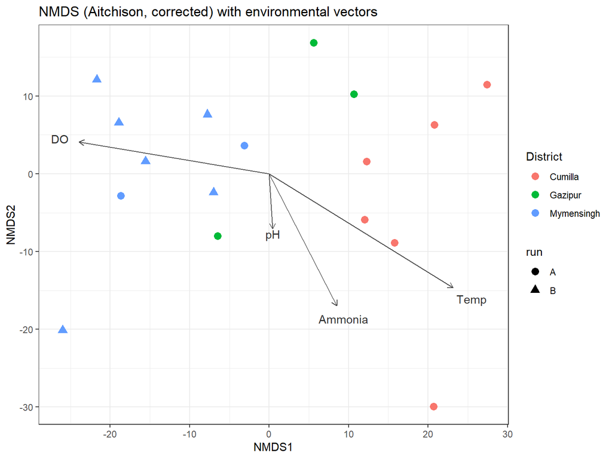

```r
arr <- as.data.frame(scores(ef, display = "vectors"))
arr <- arr * 0.8 * max(abs(nm_bc$points)) / max(abs(as.matrix(arr)))   # scale to plot
arr$var <- rownames(arr)
pts <- nmds_df[grepl("corrected", nmds_df$method), ]

ggplot(pts, aes(NMDS1, NMDS2)) +
  geom_point(aes(colour = .data[[group_col]], shape = .data[[batch_col]]), size = 3) +
  geom_segment(data = arr, aes(x = 0, y = 0, xend = NMDS1, yend = NMDS2),
               arrow = arrow(length = unit(0.2, "cm")), colour = "grey30") +
  geom_text(data = arr, aes(NMDS1 * 1.1, NMDS2 * 1.1, label = var), colour = "grey20") +
  labs(title = "NMDS (Aitchison, corrected) with environmental vectors")
```

# 8 sPLS-DA on District

Input: the batch-corrected CLR matrix `X_bc`. It is already log-ratio transformed, so `logratio = "none"`. There are no repeated measures (one row per sample), so no `multilevel`.

```r
X <- X_bc
Y <- meta[[group_col]]
summary(Y)
```

```
   Cumilla    Gazipur Mymensingh
         6          3          8
```

```r
n.folds <- min(5, min(table(Y)))    # folds cannot exceed the smallest group
lab <- tax[colnames(X), "Label"]    # "Order-Genus (ASVxx)"
```

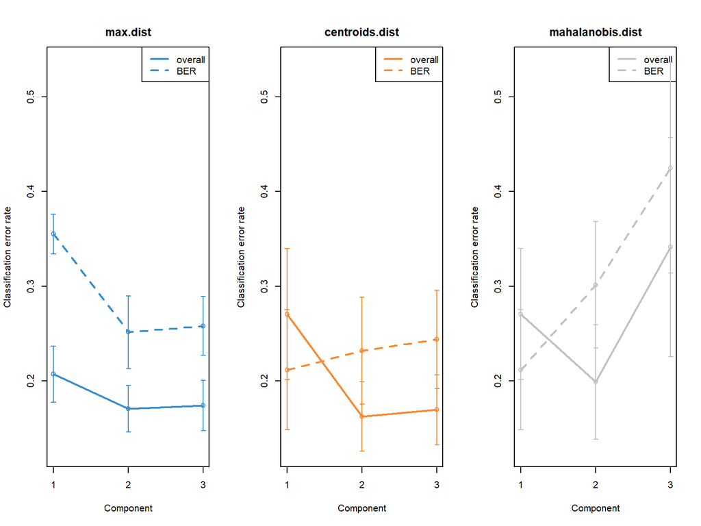

```r
plsda.basic <- mixOmics::plsda(X, Y, ncomp = max(2, nlevels(Y)), logratio = "none")
set.seed(5249)
perf.basic <- mixOmics::perf(plsda.basic, validation = "Mfold", folds = n.folds,
                             nrepeat = 50, progressBar = FALSE)
plot(perf.basic, overlay = "measure", sd = TRUE)
```

```r
ncomp.perf <- perf.basic$choice.ncomp["BER", "max.dist"]
ncomp.perf
```

```
[1] 2
```

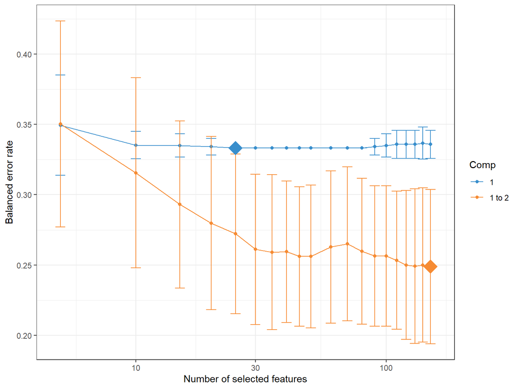

```r
grid.keepX <- c(seq(5, 50, 5), seq(60, 150, 10))
grid.keepX <- grid.keepX[grid.keepX <= ncol(X)]

set.seed(5249)
tune <- mixOmics::tune.splsda(X, Y, ncomp = max(2, ncomp.perf), logratio = "none",
                              test.keepX = grid.keepX, validation = "Mfold",
                              folds = n.folds, nrepeat = 50, dist = "max.dist",
                              measure = "BER", progressBar = FALSE)
plot(tune)
```

```r
opt.ncomp <- max(2, tune$choice.ncomp$ncomp)
opt.keepX <- tune$choice.keepX[1:opt.ncomp]
opt.ncomp; opt.keepX
```

```
[1] 2
```

```
comp1 comp2
   25   150
```

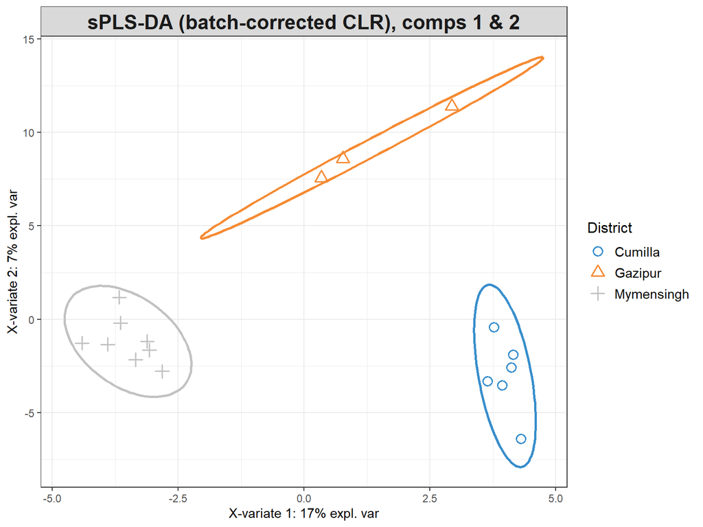

```r
splsda.final <- mixOmics::splsda(X, Y, ncomp = opt.ncomp, keepX = opt.keepX, logratio = "none")

plotIndiv(splsda.final, comp = c(1, 2), ind.names = FALSE, ellipse = TRUE, legend = TRUE,
          legend.title = group_col, title = "sPLS-DA (batch-corrected CLR), comps 1 & 2")
```

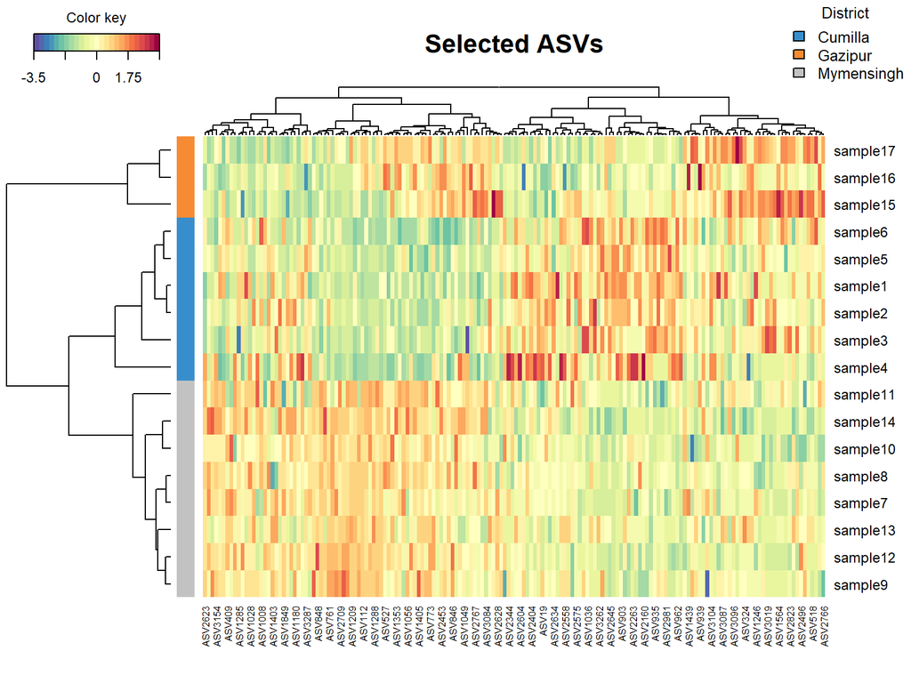

```r
cim(splsda.final, comp = 1:2,
    row.sideColors = color.mixo(as.numeric(Y)),
    legend = list(legend = levels(Y), col = color.mixo(seq_len(nlevels(Y))), title = group_col),
    title = "Selected ASVs")
```

## 8.1 Cross-validated performance

```r
set.seed(5249)
perf.final <- mixOmics::perf(splsda.final, validation = "Mfold", folds = n.folds,
                             nrepeat = 50, dist = "max.dist", progressBar = FALSE)
perf.final$error.rate          # overall error and BER per component
```

```
$overall
       max.dist
comp1 0.1764706
comp2 0.1364706

$BER
       max.dist
comp1 0.3333333
comp2 0.2488889
```

```r
perf.final$error.rate.class    # error per District
```

```
$max.dist
           comp1     comp2
Cumilla        0 0.0100000
Gazipur        1 0.7266667
Mymensingh     0 0.0100000
```

```r
cat("Chance-level BER:", round(1 - 1 / nlevels(Y), 2), "\n")
```

```
Chance-level BER: 0.67
```

## 8.2 Permutation test

Labels are shuffled **within run**, the batch correction is redone, and the model is refitted with the same ncomp/keepX. The p-value is the share of permutations with a BER as low as the real one. (Fixed keepX makes this slightly optimistic; nested tuning is more expensive.)

```r
perm_splsda <- function(clr, Y, batch, ncomp, keepX, nperm, folds, nrepeat = 10) {
  fit_ber <- function(Yuse) {
    Xb <- batch_correct(clr, batch, design = model.matrix(~ Yuse))
    m  <- mixOmics::splsda(Xb, Yuse, ncomp = ncomp, keepX = keepX)
    p  <- mixOmics::perf(m, validation = "Mfold", folds = folds, nrepeat = nrepeat,
                         dist = "max.dist", progressBar = FALSE)
    p$error.rate$BER[ncomp, "max.dist"]
  }
  obs  <- fit_ber(Y)
  null <- vapply(seq_len(nperm), function(i)
    fit_ber(Y[permute::shuffle(length(Y), control = how(blocks = batch))]), numeric(1))
  list(observed = obs, null = null, p = (sum(null <= obs) + 1) / (nperm + 1))
}

set.seed(5249)
pt_da <- perm_splsda(clr_raw, Y, meta[[batch_col]], opt.ncomp, opt.keepX,
                     nperm = params$nperm, folds = n.folds)
cat("Observed BER:", round(pt_da$observed, 3), "  permutation p =", signif(pt_da$p, 3), "\n")
```

```
Observed BER: 0.249   permutation p = 0.099
```

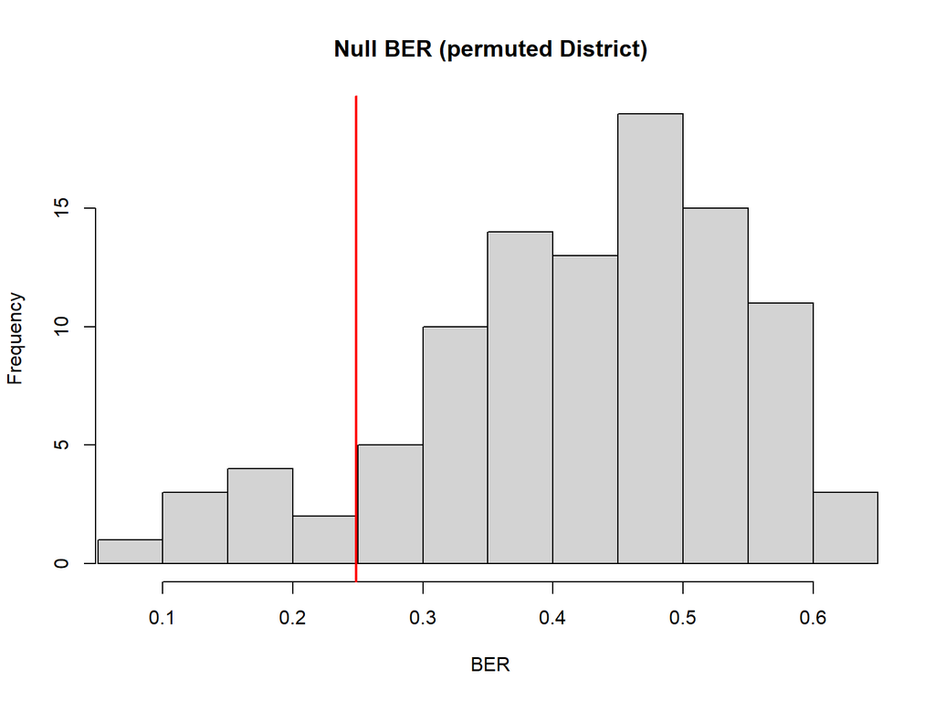

```r
hist(pt_da$null, breaks = 20, main = "Null BER (permuted District)", xlab = "BER",
     xlim = range(c(pt_da$null, pt_da$observed)))
abline(v = pt_da$observed, col = "red", lwd = 2)
```

## 8.3 Leave-one-run-out validation

The strictest check: train on all runs but one, predict the held-out run. Uses label-free per-run centering, so the held-out run never informs the correction through its labels.

```r
loro_splsda <- function(clr, Y, batch, ncomp, keepX) {
  batch <- droplevels(factor(batch))
  Xc    <- batch_correct(clr, batch, method = "center")
  pred  <- rep(NA_character_, length(Y))
  for (b in levels(batch)) {
    te <- batch == b; tr <- !te
    if (nlevels(droplevels(Y[tr])) < nlevels(Y)) {
      message("Run ", b, " skipped: training set lacks some Districts"); next
    }
    ok <- apply(Xc[tr, ], 2, sd) > 1e-8
    m  <- mixOmics::splsda(Xc[tr, ok], droplevels(Y[tr]), ncomp = ncomp,
                           keepX = pmin(keepX, sum(ok)))
    pred[te] <- predict(m, Xc[te, ok, drop = FALSE], dist = "max.dist")$class$max.dist[, ncomp]
  }
  tab <- table(observed = Y, predicted = factor(pred, levels = levels(Y)))
  list(table = tab, BER = mean(1 - diag(tab) / rowSums(tab), na.rm = TRUE))
}

loro <- loro_splsda(clr_raw, Y, meta[[batch_col]], opt.ncomp, opt.keepX)
loro$table
```

```
            predicted
observed     Cumilla Gazipur Mymensingh
  Cumilla          0       0          0
  Gazipur          0       0          0
  Mymensingh       5       1          0
```

```r
cat("Leave-one-run-out BER:", round(loro$BER, 3), "\n")
```

```
Leave-one-run-out BER: 1
```

## 8.4 Discriminating ASVs (Order-Genus)

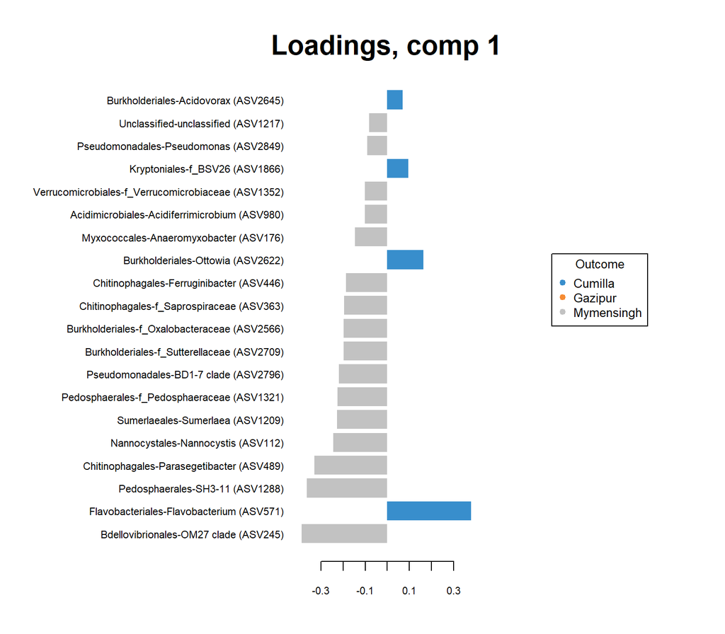

```r
plotLoadings(splsda.final, comp = 1, method = "mean", contrib = "max",
             name.var = lab, size.name = 0.7, ndisplay = 20, title = "Loadings, comp 1")
```

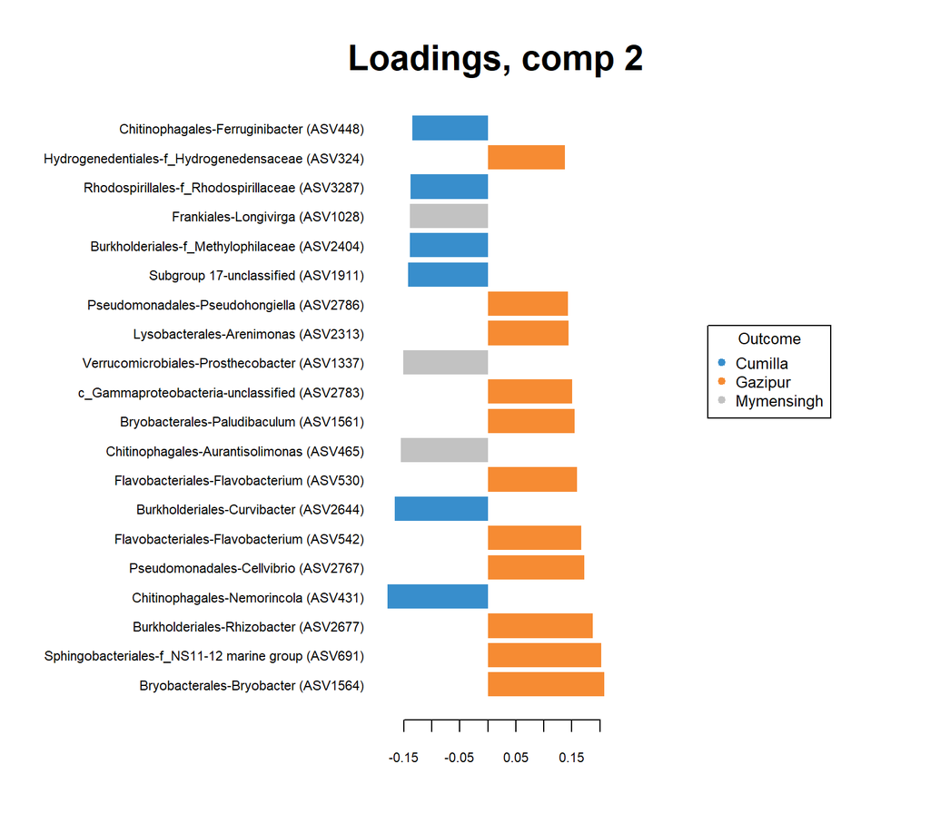

```r
plotLoadings(splsda.final, comp = 2, method = "mean", contrib = "max",
             name.var = lab, size.name = 0.7, ndisplay = 20, title = "Loadings, comp 2")
```

```r
splsda_drivers <- do.call(rbind, lapply(seq_len(opt.ncomp), function(k) {
  sel <- selectVar(splsda.final, comp = k)$value
  asv <- rownames(sel)
  stab <- perf.final$features$stable[[k]]
  data.frame(comp = k, ASV = asv, OrderGenus = tax[asv, "OrderGenus"],
             loading = sel$value.var,
             stability = ifelse(asv %in% names(stab), as.numeric(stab[asv]), 0),
             tax[asv, intersect(c("Phylum", "Class", "Order", "Family", "Genus"), names(tax))],
             row.names = NULL)
}))
head(splsda_drivers[order(splsda_drivers$comp, -abs(splsda_drivers$loading)), ], 30)
```

```
   comp     ASV                                OrderGenus       loading
1     1  ASV245              Bdellovibrionales-OM27 clade -0.3870242865
2     1  ASV571           Flavobacteriales-Flavobacterium  0.3798262814
3     1 ASV1288                     Pedosphaerales-SH3-11 -0.3637887035
4     1  ASV489          Chitinophagales-Parasegetibacter -0.3297950699
5     1  ASV112                 Nannocystales-Nannocystis -0.2444038588
6     1 ASV1209                    Sumerlaeales-Sumerlaea -0.2278953967
7     1 ASV1321          Pedosphaerales-f_Pedosphaeraceae -0.2265236444
8     1 ASV2796               Pseudomonadales-BD1-7 clade -0.2190967584
9     1 ASV2709          Burkholderiales-f_Sutterellaceae -0.1982122475
10    1 ASV2566        Burkholderiales-f_Oxalobacteraceae -0.1978530306
11    1  ASV363          Chitinophagales-f_Saprospiraceae -0.1961620837
12    1  ASV446           Chitinophagales-Ferruginibacter -0.1874152233
13    1 ASV2622                   Burkholderiales-Ottowia  0.1633372395
14    1  ASV176             Myxococcales-Anaeromyxobacter -0.1461004998
```

[output cut: 78 more lines]

```r
write.csv(splsda_drivers, "sPLSDA_District_drivers.csv", row.names = FALSE)
```

**Tip**

Report ASVs with high |loading| **and** stability ≥ 0.6–0.8 (selected in most CV folds).

# 9 sPLS regression on pH, DO, Temp, Ammonia

One sPLS1 model per variable. For each variable:

1. drop samples with a missing value;
2. batch-correct the CLR matrix, protecting that variable (`design = ~ y`);
3. tune ncomp and keepX by leave-one-out Q² (Q² > 0 means better than predicting the mean);
4. permutation test (y shuffled within run, correction and tuning redone);
5. rank driver ASVs by loading, VIP and selection frequency, labelled Order-Genus.

## 9.1 Environmental variables first

```r
round(cor(meta[, env_vars], use = "pairwise.complete.obs", method = "spearman"), 2)
```

```
           pH    DO  Temp Ammonia
pH       1.00 -0.11  0.07   -0.10
DO      -0.11  1.00 -0.33    0.10
Temp     0.07 -0.33  1.00    0.59
Ammonia -0.10  0.10  0.59    1.00
```

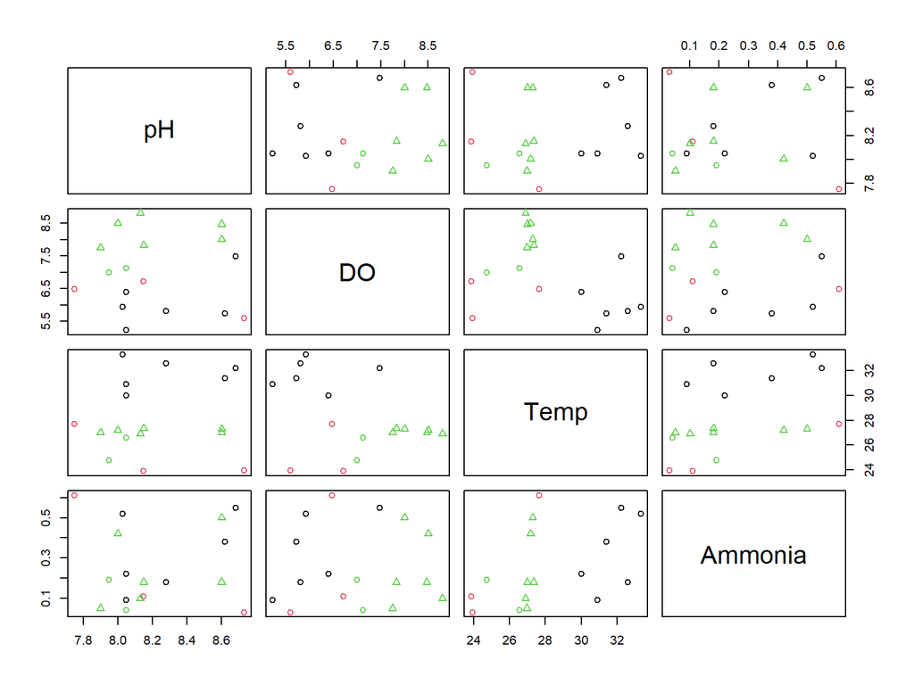

```r
pairs(meta[, env_vars], col = as.numeric(meta[[group_col]]), pch = as.numeric(meta[[batch_col]]))
```

## 9.2 Helper functions

```r
## Cross-validated sPLS1; returns Q2, RMSEP, r(pred, obs) and selection frequency
cv_spls1 <- function(X, y, keepX, ncomp = 1, folds = length(y), nrepeat = 1,
                     return_sel = FALSE) {
  n <- length(y)
  pred <- matrix(NA_real_, n, nrepeat)
  sel <- character(0); nfit <- 0
  for (r in seq_len(nrepeat)) {
    fid <- if (folds >= n) seq_len(n) else sample(rep(seq_len(folds), length.out = n))
    for (k in unique(fid)) {
      te <- which(fid == k); tr <- setdiff(seq_len(n), te)
      ok <- apply(X[tr, , drop = FALSE], 2, sd) > 1e-8     # drop constant ASVs in training
      m  <- mixOmics::spls(X[tr, ok, drop = FALSE], y[tr], ncomp = ncomp,
                           keepX = rep(min(keepX, sum(ok)), ncomp), mode = "regression")
      pred[te, r] <- predict(m, newdata = X[te, ok, drop = FALSE])$predict[, 1, ncomp]
      if (return_sel) {
        sel  <- c(sel, mixOmics::selectVar(m, comp = 1)$X$name)
        nfit <- nfit + 1
      }
    }
  }
  tss <- sum((y - mean(y))^2)
  out <- list(Q2    = mean(apply(pred, 2, function(p) 1 - sum((y - p)^2) / tss)),
              RMSEP = mean(apply(pred, 2, function(p) sqrt(mean((y - p)^2)))),
              r     = cor(y, rowMeans(pred)),
              pred  = rowMeans(pred))
  if (return_sel) out$sel_freq <- table(sel) / nfit
  out
}

## Grid search over ncomp x keepX
tune_spls1 <- function(X, y, keepX_grid, ncomp_grid = 1:2) {
  res <- expand.grid(ncomp = ncomp_grid, keepX = keepX_grid[keepX_grid <= ncol(X)])
  cv  <- lapply(seq_len(nrow(res)), function(i) cv_spls1(X, y, res$keepX[i], res$ncomp[i]))
  res$Q2    <- sapply(cv, `[[`, "Q2")
  res$RMSEP <- sapply(cv, `[[`, "RMSEP")
  res$r     <- sapply(cv, `[[`, "r")
  list(table = res, best = res[which.max(res$Q2), ])
}

grid.keepX.reg <- c(5, 10, 15, 20, 30, 50, 75, 100)
```

## 9.3 Fit, validate and test each variable

```r
set.seed(5249)
reg_res <- lapply(env_vars, function(v) {
  cc <- !is.na(meta[[v]])
  y  <- meta[[v]][cc]
  cl <- clr_raw[cc, ]
  b  <- droplevels(meta[[batch_col]][cc])
  make_X <- function(yy) batch_correct(cl, b, design = model.matrix(~ yy))

  Xv   <- make_X(y)
  tun  <- tune_spls1(Xv, y, grid.keepX.reg)
  best <- tun$best
  cvb  <- cv_spls1(Xv, y, best$keepX, best$ncomp, return_sel = TRUE)

  # Permutation null for Q2 (shuffle within run; redo correction [+ tuning])
  null <- vapply(seq_len(params$nperm), function(i) {
    yp <- y[permute::shuffle(length(y), control = how(blocks = b))]
    Xp <- make_X(yp)
    if (isTRUE(params$perm_tune)) tune_spls1(Xp, yp, grid.keepX.reg)$best$Q2
    else cv_spls1(Xp, yp, best$keepX, best$ncomp)$Q2
  }, numeric(1))

  # Final model on all samples
  fit <- mixOmics::spls(Xv, y, ncomp = best$ncomp, keepX = rep(best$keepX, best$ncomp),
                        mode = "regression")
  vipm <- mixOmics::vip(fit)
  sel  <- mixOmics::selectVar(fit, comp = 1)$X$value
  asv  <- rownames(sel)
  sf   <- cvb$sel_freq

  drivers <- data.frame(
    variable   = v,
    ASV        = asv,
    OrderGenus = tax[asv, "OrderGenus"],
    loading    = sel$value.var,
    VIP        = vipm[asv, best$ncomp],
    sel_freq   = ifelse(asv %in% names(sf), as.numeric(sf[asv]), 0),
    spearman   = sapply(asv, function(a) cor(Xv[, a], y, method = "spearman")),
    tax[asv, intersect(c("Phylum", "Class", "Order", "Family", "Genus"), names(tax))],
    row.names = NULL)
  drivers <- drivers[order(-abs(drivers$loading)), ]

  list(variable = v, n = sum(cc), tuning = tun$table, best = best, cv = cvb,
       null = null, p = (sum(null >= best$Q2) + 1) / (params$nperm + 1),
       y = y, fit = fit, drivers = drivers, samples = rownames(cl))
})
names(reg_res) <- env_vars
```

## 9.4 Model performance

```r
reg_summary <- do.call(rbind, lapply(reg_res, function(r) data.frame(
  variable = r$variable, n = r$n, ncomp = r$best$ncomp, keepX = r$best$keepX,
  Q2 = round(r$best$Q2, 3), RMSEP = signif(r$best$RMSEP, 3), r_pred_obs = round(r$best$r, 2),
  null_Q2_95 = round(quantile(r$null, 0.95), 3), perm_p = signif(r$p, 3))))
reg_summary
```

```
        variable  n ncomp keepX     Q2 RMSEP r_pred_obs null_Q2_95 perm_p
pH            pH 17     2    30 -0.083 0.310       0.17      0.514 0.7820
DO            DO 17     2    15  0.788 0.501       0.90      0.924 0.4650
Temp        Temp 17     2   100  0.758 1.420       0.88      0.643 0.0099
Ammonia  Ammonia 17     1    50  0.222 0.168       0.48      0.588 0.3760
```

```r
write.csv(reg_summary, "sPLS_env_performance.csv", row.names = FALSE)
```

**NoteHow to read this**

- **Q² ≤ 0**: the community does not predict the variable better than its mean.
- **Q² > 0 and perm_p < 0.05**: predictive signal; interpret the driver ASVs.
- With `perm_tune: true` the null is tuned the same way as the real model, so it is fair even though the best Q² was picked from a grid.

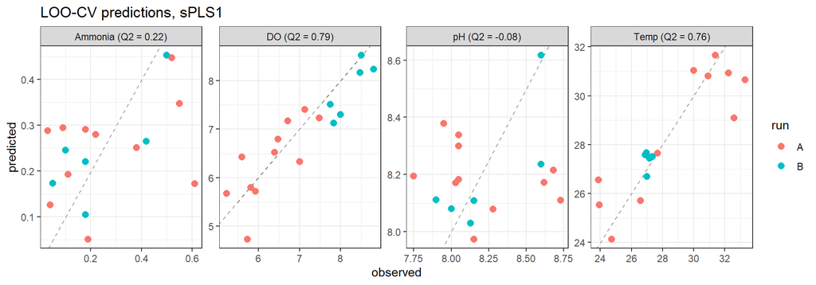

```r
op <- do.call(rbind, lapply(reg_res, function(r)
  data.frame(variable = paste0(r$variable, " (Q2 = ", round(r$best$Q2, 2), ")"),
             observed = r$y, predicted = r$cv$pred,
             run = meta[r$samples, batch_col])))
ggplot(op, aes(observed, predicted, colour = run)) +
  geom_abline(linetype = 2, colour = "grey50") +
  geom_point(size = 2.5) +
  facet_wrap(~ variable, scales = "free", nrow = 1) +
  labs(title = "LOO-CV predictions, sPLS1")
```

## 9.5 Driver ASVs (Order-Genus)

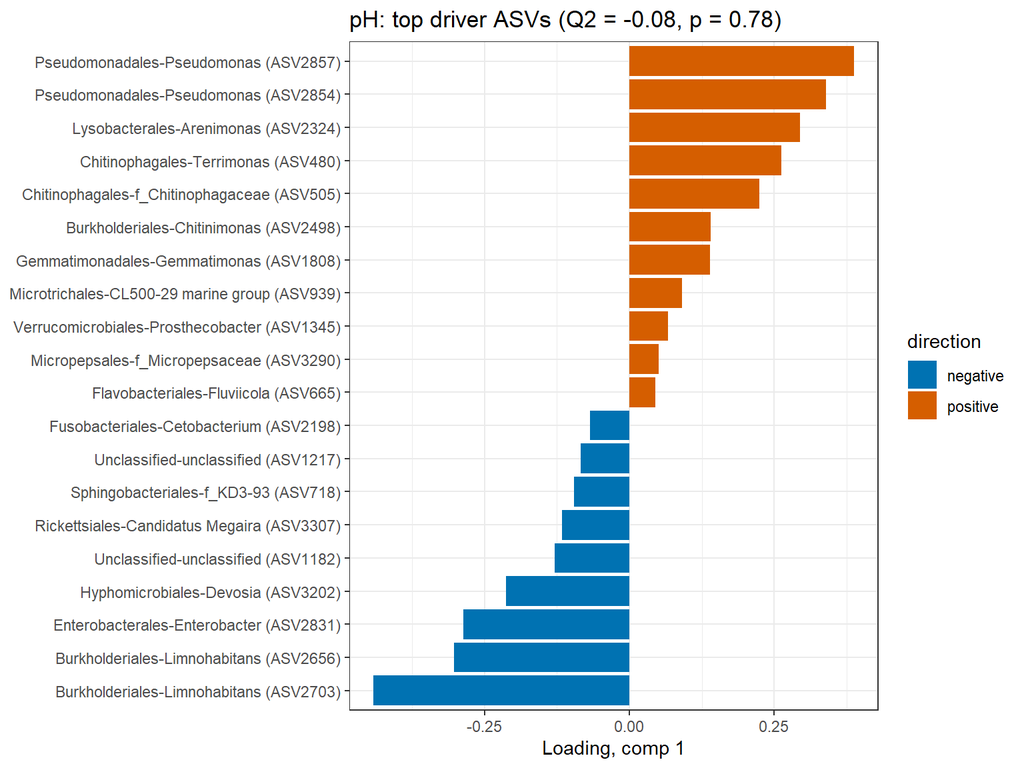

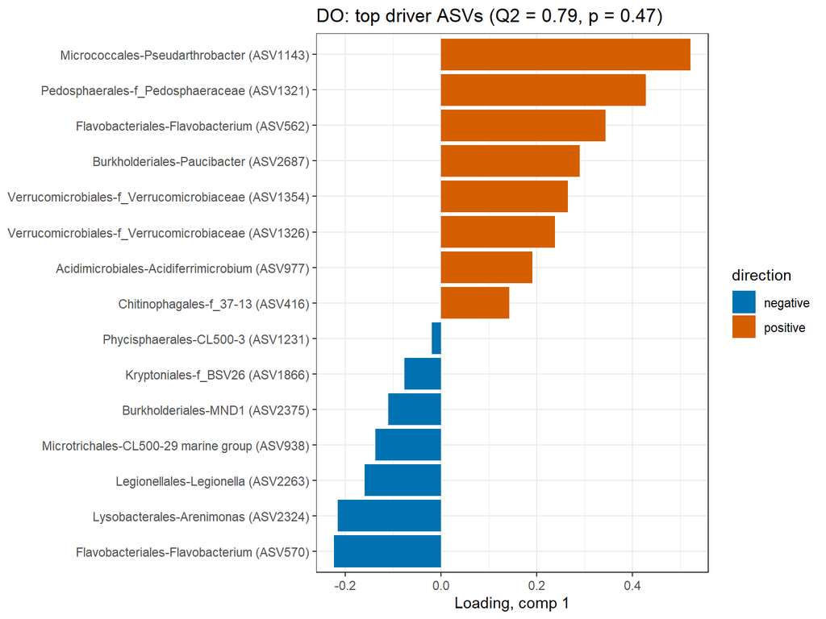

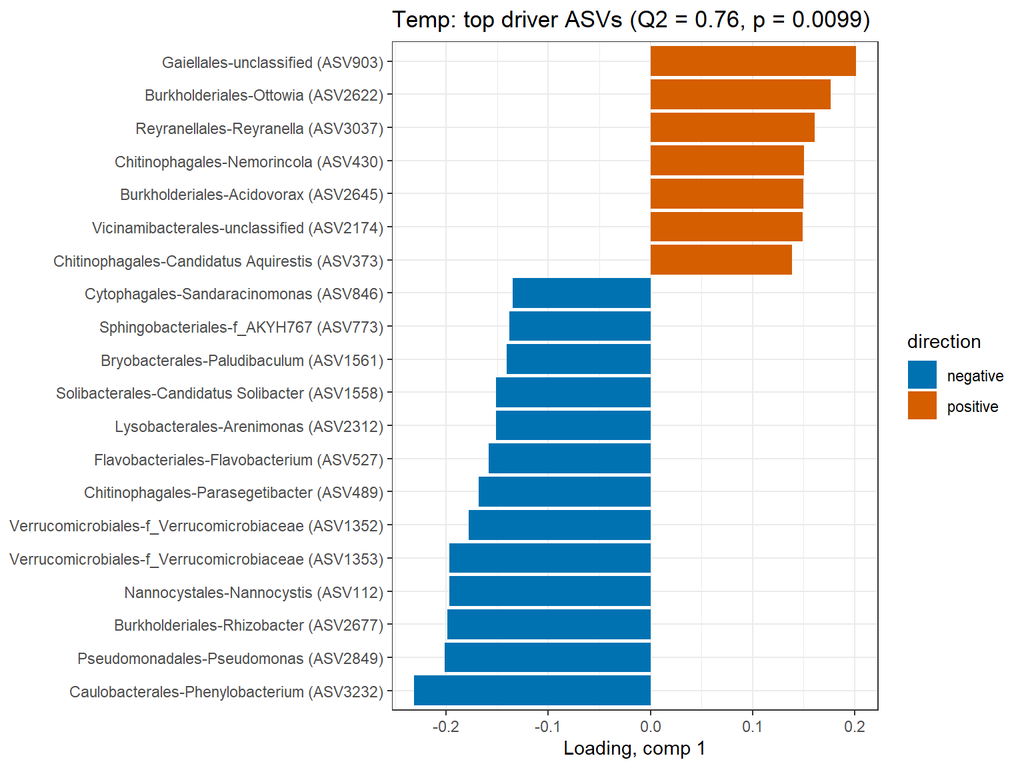

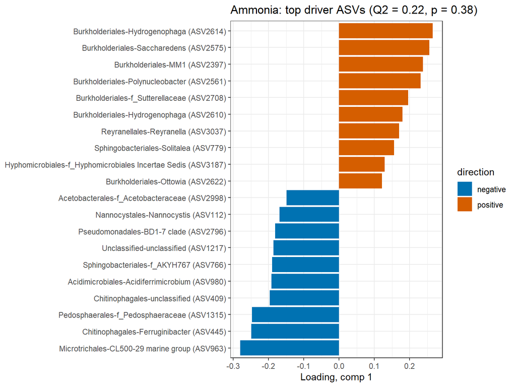

```r
for (r in reg_res) {
  top <- head(r$drivers, 20)
  top$Label <- paste0(top$OrderGenus, " (", top$ASV, ")")
  top$direction <- ifelse(top$spearman > 0, "positive", "negative")
  print(
    ggplot(top, aes(reorder(Label, loading), loading, fill = direction)) +
      geom_col() + coord_flip() +
      scale_fill_manual(values = c(positive = "#D55E00", negative = "#0072B2")) +
      labs(x = NULL, y = "Loading, comp 1",
           title = paste0(r$variable, ": top driver ASVs (Q2 = ", round(r$best$Q2, 2),
                          ", p = ", signif(r$p, 2), ")"))
  )
}
```

```r
drivers_all <- do.call(rbind, lapply(reg_res, `[[`, "drivers"))
write.csv(drivers_all, "sPLS_env_driver_ASVs.csv", row.names = FALSE)
head(drivers_all[drivers_all$sel_freq >= 0.6, c("variable", "ASV", "OrderGenus",
                                                "loading", "VIP", "sel_freq", "spearman")], 40)
```

```
       variable     ASV                                 OrderGenus     loading
pH.1         pH ASV2703              Burkholderiales-Limnohabitans -0.44148549
pH.2         pH ASV2857                Pseudomonadales-Pseudomonas  0.38713741
pH.3         pH ASV2854                Pseudomonadales-Pseudomonas  0.33903877
pH.4         pH ASV2656              Burkholderiales-Limnohabitans -0.30212300
pH.5         pH ASV2324                  Lysobacterales-Arenimonas  0.29476518
pH.6         pH ASV2831              Enterobacterales-Enterobacter -0.28684565
pH.7         pH  ASV480                 Chitinophagales-Terrimonas  0.26211511
pH.8         pH  ASV505         Chitinophagales-f_Chitinophagaceae  0.22426893
pH.9         pH ASV3202                   Hyphomicrobiales-Devosia -0.21281299
pH.10        pH ASV2498               Burkholderiales-Chitinimonas  0.13991167
pH.11        pH ASV1808              Gemmatimonadales-Gemmatimonas  0.13942762
pH.12        pH ASV1182                  Unclassified-unclassified -0.12894187
pH.13        pH ASV3307           Rickettsiales-Candidatus Megaira -0.11650721
pH.14        pH  ASV718                Sphingobacteriales-f_KD3-93 -0.09617603
pH.15        pH  ASV939       Microtrichales-CL500-29 marine group  0.09081561
pH.16        pH ASV1217                  Unclassified-unclassified -0.08466433
pH.17        pH ASV2198              Fusobacteriales-Cetobacterium -0.06788074
pH.18        pH ASV1345         Verrucomicrobiales-Prosthecobacter  0.06690879
pH.19        pH ASV3290             Micropepsales-f_Micropepsaceae  0.05007742
pH.20        pH  ASV665                Flavobacteriales-Fluviicola  0.04474946
pH.24        pH ASV2977 Paracaedibacterales-f_Paracaedibacteraceae -0.03210313
pH.25        pH ASV3111            Hyphomicrobiales-Bradyrhizobium  0.03076847
DO.1         DO ASV1143            Micrococcales-Pseudarthrobacter  0.52114996
DO.2         DO ASV1321           Pedosphaerales-f_Pedosphaeraceae  0.42814410
DO.3         DO  ASV562            Flavobacteriales-Flavobacterium  0.34359471
DO.4         DO ASV2687                Burkholderiales-Paucibacter  0.29016743
DO.5         DO ASV1354   Verrucomicrobiales-f_Verrucomicrobiaceae  0.26590105
DO.6         DO ASV1326   Verrucomicrobiales-f_Verrucomicrobiaceae  0.23843076
DO.7         DO  ASV570            Flavobacteriales-Flavobacterium -0.22289831
DO.8         DO ASV2324                  Lysobacterales-Arenimonas -0.21491569
DO.9         DO  ASV977       Acidimicrobiales-Acidiferrimicrobium  0.19152273
DO.10        DO ASV2263                   Legionellales-Legionella -0.15952867
DO.11        DO  ASV416                    Chitinophagales-f_37-13  0.14304854
DO.12        DO  ASV938       Microtrichales-CL500-29 marine group -0.13699672
DO.13        DO ASV2375                       Burkholderiales-MND1 -0.10942985
DO.14        DO ASV1866                       Kryptoniales-f_BSV26 -0.07566419
Temp.1     Temp ASV3232           Caulobacterales-Phenylobacterium -0.23121273
Temp.2     Temp ASV2849                Pseudomonadales-Pseudomonas -0.20134985
Temp.3     Temp  ASV903                    Gaiellales-unclassified  0.20116848
```

[output cut: 27 more lines]

```
DO.4    6.1346413 1.0000000  0.82598039
DO.5    5.6216081 1.0000000  0.75735294
DO.6    5.0408385 1.0000000  0.68137255
DO.7    4.7124557 1.0000000 -0.69852941
DO.8    4.5436893 1.0000000 -0.83333333
DO.9    4.0491217 1.0000000  0.75980392
DO.10   3.3727119 1.0000000 -0.85784314
DO.11   3.0242935 0.8823529  0.62009804
DO.12   2.8963476 0.8235294 -0.75245098
DO.13   2.3135363 0.8235294 -0.75735294
DO.14   1.5996719 0.6470588 -0.72549020
Temp.1  4.8780889 1.0000000 -0.80882353
Temp.2  4.2480465 1.0000000 -0.84068627
Temp.3  4.2442201 1.0000000  0.73774510
Temp.4  4.1968608 1.0000000 -0.57352941
```

## 9.6 Driver × variable heatmap (within-run correlations)

ASVs and environmental variables are both centred within run before correlating, so the correlations are not driven by run differences.

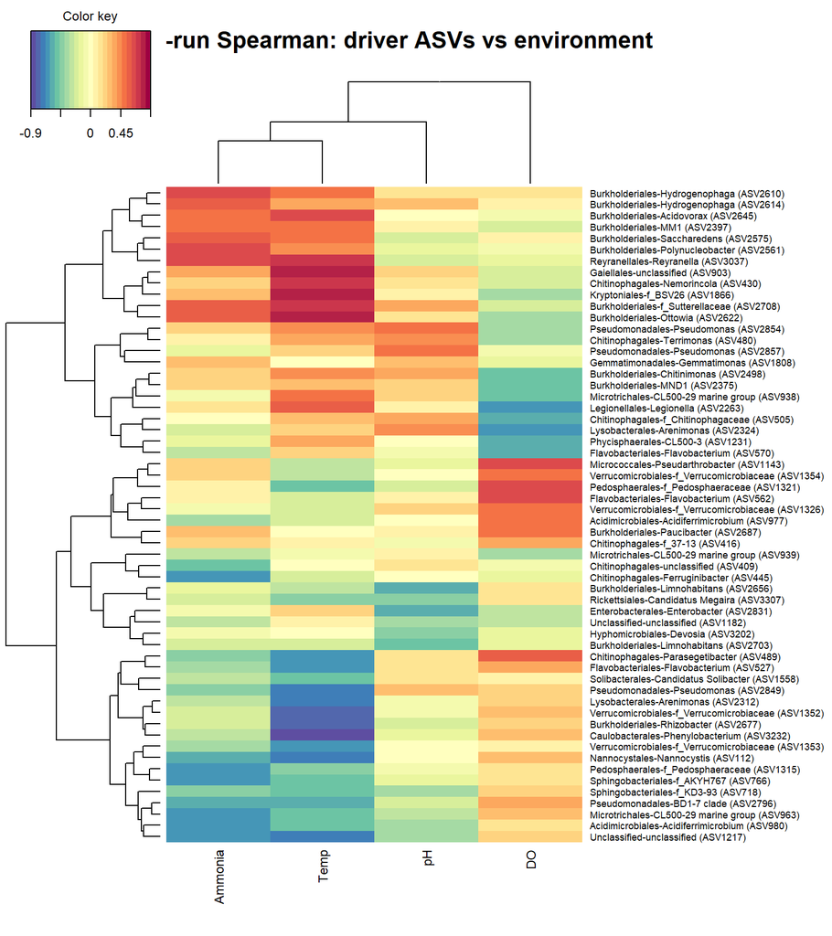

```r
top_asv <- unique(unlist(lapply(reg_res, function(r) head(r$drivers$ASV, 15))))
Xc  <- batch_correct(clr_raw, meta[[batch_col]], method = "center")[, top_asv]
Ec  <- sapply(env_vars, function(v) meta[[v]] - ave(meta[[v]], meta[[batch_col]],
                                                    FUN = function(z) mean(z, na.rm = TRUE)))
cmat <- cor(Xc, Ec, method = "spearman", use = "pairwise.complete.obs")
rownames(cmat) <- tax[top_asv, "Label"]
cmat[is.na(cmat)] <- 0   # a variable constant within every run gives NA
cim(cmat, margins = c(6, 16), title = "Within-run Spearman: driver ASVs vs environment")
```

## 9.7 Joint model: RDA with run as a conditioning variable

A classical companion to sPLS: how much community variation the four variables explain together, after removing run.

```r
cc  <- complete.cases(meta[, env_vars])
Yc  <- clr_raw[cc, ]
env_s <- data.frame(scale(meta[cc, env_vars]), meta[cc, batch_col, drop = FALSE],
                    check.names = FALSE)

rda_env <- vegan::rda(as.formula(paste("Yc ~", paste(env_vars, collapse = " + "),
                                       "+ Condition(", batch_col, ")")), data = env_s)
RsquareAdj(rda_env)
```

```
$r.squared
[1] 0.1755171

$adj.r.squared
[1] 0.02139012
```

```r
vif.cca(rda_env)                                  # > 10 = collinear variables
```

```
    runB       pH       DO     Temp  Ammonia
3.568749 1.014050 4.007784 1.602496 1.430453
```

```r
anova(rda_env, permutations = 999)                # global test
```

```
Permutation test for rda under reduced model
Permutation: free
Number of permutations: 999

Model: rda(formula = Yc ~ pH + DO + Temp + Ammonia + Condition(run), data = env_s)
         Df Variance     F Pr(>F)
Model     4   302.48 1.129  0.132
Residual 11   736.79
```

```r
anova(rda_env, by = "margin", permutations = 999) # each variable given the others
```

```
Permutation test for rda under reduced model
Marginal effects of terms
Permutation: free
Number of permutations: 999

Model: rda(formula = Yc ~ pH + DO + Temp + Ammonia + Condition(run), data = env_s)
         Df Variance      F Pr(>F)
pH        1    49.79 0.7433  0.906
DO        1    52.43 0.7828  0.866
Temp      1   106.58 1.5911  0.015 *
Ammonia   1    70.42 1.0513  0.386
Residual 11   736.79
---
Signif. codes:  0 '***' 0.001 '**' 0.01 '*' 0.05 '.' 0.1 ' ' 1
```

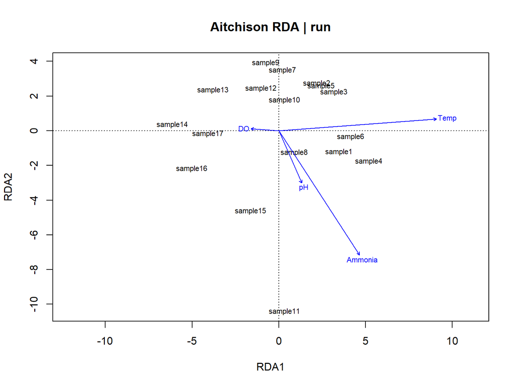

```r
plot(rda_env, display = c("sites", "bp"), main = "Aitchison RDA | run")
```

# 10 Other ML approaches

## 10.1 Random Forest at genus level

```r
library(ranger)
G_raw <- t(rowsum(t(X_raw), group = tax[colnames(X_raw), "OrderGenus"]))   # samples x genera
G_raw <- G_raw[, colSums(G_raw) / sum(G_raw) > 1e-4 & colSums(G_raw > 0) >= 2]
G_bc  <- batch_correct(clr(G_raw + 1), meta[[batch_col]], method = "center")
g_map <- setNames(colnames(G_bc), paste0("G", seq_len(ncol(G_bc))))        # safe names
colnames(G_bc) <- names(g_map)
dim(G_bc)
```

```
[1]  17 268
```

```r
loo_rf <- function(Xdf, y, num.trees = 1000) {
  pred <- vector("list", length(y))
  for (i in seq_along(y)) {
    m <- ranger::ranger(x = Xdf[-i, , drop = FALSE], y = y[-i], num.trees = num.trees,
                        seed = 5249 + i)
    pred[[i]] <- predict(m, data = Xdf[i, , drop = FALSE])$predictions
  }
  if (is.factor(y)) factor(sapply(pred, as.character), levels = levels(y)) else unlist(pred)
}
bal_acc <- function(obs, pred) { t <- table(obs, pred); mean(diag(t) / rowSums(t)) }
```

```r
# Does the microbiome add beyond the environment? (complete cases only)
cc  <- complete.cases(meta[, env_vars])
Yd  <- droplevels(meta[[group_col]][cc])
sets <- list(
  microbiome  = as.data.frame(G_bc[cc, ]),
  environment = meta[cc, env_vars, drop = FALSE],
  both        = cbind(as.data.frame(G_bc[cc, ]), meta[cc, env_vars, drop = FALSE])
)
rf_district <- sapply(sets, function(s) round(bal_acc(Yd, loo_rf(s, Yd)), 2))
rf_district
```

```
 microbiome environment        both
       0.25        0.72        0.46
```

```r
cat("Chance balanced accuracy:", round(1 / nlevels(Yd), 2), "\n")
```

```
Chance balanced accuracy: 0.33
```

```r
# Permutation importance from the full microbiome model
rf_full <- ranger::ranger(x = as.data.frame(G_bc), y = meta[[group_col]], num.trees = 2000,
                          importance = "permutation", seed = 5249)
imp <- sort(rf_full$variable.importance, decreasing = TRUE)[1:20]
data.frame(OrderGenus = g_map[names(imp)], importance = round(imp, 4), row.names = NULL)
```

```
                                 OrderGenus importance
1                 Nannocystales-Nannocystis     0.0062
2             Sphingobacteriales-Pedobacter     0.0053
3               Burkholderiales-Rhizobacter     0.0047
4        Burkholderiales-f_Oxalobacteraceae     0.0036
5                     Frankiales-Longivirga     0.0032
6                 Lysobacterales-Arenimonas     0.0028
7                   Gaiellales-unclassified     0.0024
8                     Frankiales-hgcI clade     0.0022
9                        R7C24-unclassified     0.0021
10              Chitinophagales-Nemorincola     0.0020
11             Burkholderiales-Rugosibacter     0.0019
12              Parvibaculales-Parvibaculum     0.0018
13 Vicinamibacterales-f_Vicinamibacteraceae     0.0017
14                  Burkholderiales-Ottowia     0.0017
15              Burkholderiales-Curvibacter     0.0016
16                 Subgroup 17-unclassified     0.0012
17               Burkholderiales-Rubrivivax     0.0008
18             Bdellovibrionales-OM27 clade     0.0008
19              Pseudomonadales-BD1-7 clade     0.0008
20     Rhodospirillales-f_Rhodospirillaceae     0.0007
```

```r
# RF regression for each environmental variable (LOO Q2), to compare with sPLS
rf_env <- sapply(env_vars, function(v) {
  ok <- !is.na(meta[[v]])
  y  <- meta[[v]][ok]
  p  <- loo_rf(as.data.frame(G_bc[ok, ]), y)
  round(1 - sum((y - p)^2) / sum((y - mean(y))^2), 3)
})
data.frame(variable = env_vars, Q2_RF = rf_env, Q2_sPLS = reg_summary$Q2)
```

```
        variable  Q2_RF Q2_sPLS
pH            pH -0.288  -0.083
DO            DO -0.207   0.788
Temp        Temp  0.213   0.758
Ammonia  Ammonia  0.043   0.222
```

## 10.2 Further suggestions

| Method | Why it fits this study | R package |
| --- | --- | --- |
| **Log-ratio signatures** (balances) | Finds a small set of taxa ratios that predict the outcome; built for compositional data and small n; very interpretable | `coda4microbiome`, `selbal` |
| **Elastic net** with nested CV | Sparse linear baseline for District and env variables; compare to sPLS | `glmnet`, `mikropml` |
| **Differential abundance with run as covariate** | Confirms sPLS/RF driver taxa with a formal model (`~ District + run`, `~ pH + run`) | `ANCOMBC` (ANCOM-BC2), `Maaslin3`, `LinDA` (`MicrobiomeStat`) |
| **Count-level batch correction** | Corrects counts (not CLR), so Bray–Curtis and DA tools can use corrected data | `ConQuR`, `MMUPHin` |
| **Mixed models for alpha diversity** | `Shannon ~ District + (1 \| run)` treats run as random | `lme4`, `glmmTMB` |
| **SHAP for the RF model** | Per-sample explanation of which genera push predictions | `kernelshap` + `shapviz` |
| **Genus vs ASV sensitivity** | Rerun sPLS-DA on `G_bc`; drivers that appear at both levels are more convincing | – |
| **Sample-size planning** | The permutation nulls show the effect size you can detect; use them to argue for more samples per District/run | – |

**WarningReporting checklist**

- State the batch correction used and show the before/after variance partitioning.
- Report CV error **and** permutation p-values for every supervised model; treat leave-one-run-out as the most realistic estimate.
- Call driver ASVs “associated with”, not “causing”, the outcome.